# Perfect circle

Steve Simon

October 13, 2016

When you try to draw a circle on a graph, it often ends up looking like an ellipse. Here’s an example.

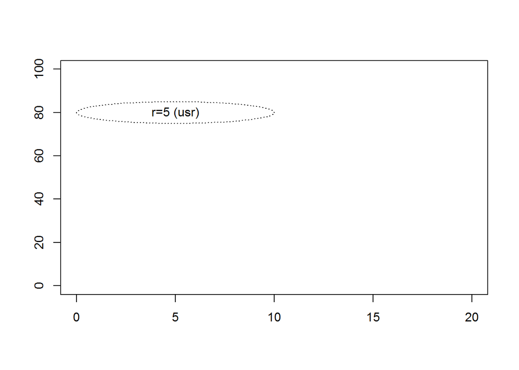

```r
draw.circle <- function(x0, y0, r, ...) {
  # draw a circle of radius r centered at x0, y0
  pi.seq <- seq(0, 2*pi, length=100)
  x.circle <- x0 + r * cos(pi.seq)
  y.circle <- y0 + r * sin(pi.seq)
  polygon(x.circle, y.circle, ...)
}
plot(0, 0, xlim=c(0, 20), ylim=c(0, 100), type="n", xlab=" ", ylab=" ")
draw.circle(5, 80, 5, lty="dotted")
text(5, 80, "r=5 (usr)")
```

```r
dv <- dev.size()
ma <- par("mai")
us <- par("usr")
```

There are three things that are contributing to this problem.

1. The default graph in R Markdown is rectangular. You can measure the size of a graph in inches with the dev.size() function: 7, 5
2. The default margins are uneven with more margins on the top and bottom compared to the left and right sides. You can measure the size of the margins in inches with par(“mai”): 1.02, 0.82, 0.82, 0.42. The size of the bottom margin is listed first, followed by the left, top, and right margins.
3. The number of units on this graph are different for the x-axis and the y-axis. You can measure the minimum and maximum values on the x and y axes using par(“usr”): -0.8, 20.8, -4, 104. Note that, by default, R adds an extra 4% to each end of the axis to reduce problems with clipping.

It’s not necessarily bad to see an ellipse where you were expecting a circle. But if you do want a perfect circle, you need to calculate the size of the plotting region and adjust appropriately.

```r
draw.circle <- function(x0, y0, r, adjust.units=function() {list(x=1, y=1)}, ...) {
  # draw a circle of radius r centered at x0, y0
  # with an adjustment in the horizontal and vertical dimensions
  # The default adjustment is no adjustment
  pi.seq <- seq(0, 2*pi, length=100)
  adj <- adjust.units()
  x.circle <- x0 + adj$x * r * cos(pi.seq)
  y.circle <- y0 + adj$y * r * sin(pi.seq)
  polygon(x.circle, y.circle, ...)
}

convert_to_inches <- function() {
  # This funciton adjusts from user coordinates to inches.
  # There is a short-cut: ratio <- par("cxy") / par("cin")

  # Range of the plotting region in user coordinates
  plot.range.usr <- c(par("usr")[2] - par("usr")[1], par("usr")[4] - par("usr")[3])
  if (verbose) cat("\nThe range of the plotting region is", plot.range.usr, "in user coordinates")

  # Range of the plotting region in inches
  plot.range.in <- par("pin")
  if (verbose) cat("\nThe range of the plotting region is", plot.range.in, "in inches")

  # Number of inches per user coordinate
  ratio <- plot.range.usr / plot.range.in
  if (verbose) cat("\nThere are", ratio, "user coordinates per inch")
  return(list(x=ratio[1], y=ratio[2]))
}

plot(0, 0, xlim=c(0, 20), ylim=c(0, 100), type="n", xlab=" ", ylab=" ")
draw.circle( 5, 80, 5, lty="dotted")
text( 5, 80, "r=5 (usr)")
verbose <- TRUE
draw.circle(15, 80, 0.5, convert_to_inches, col="red")
```

```
##
## The range of the plotting region is 21.6 108 in user coordinates
## The range of the plotting region is 5.759999 3.159999 in inches
## There are 3.75 34.17722 user coordinates per inch
```

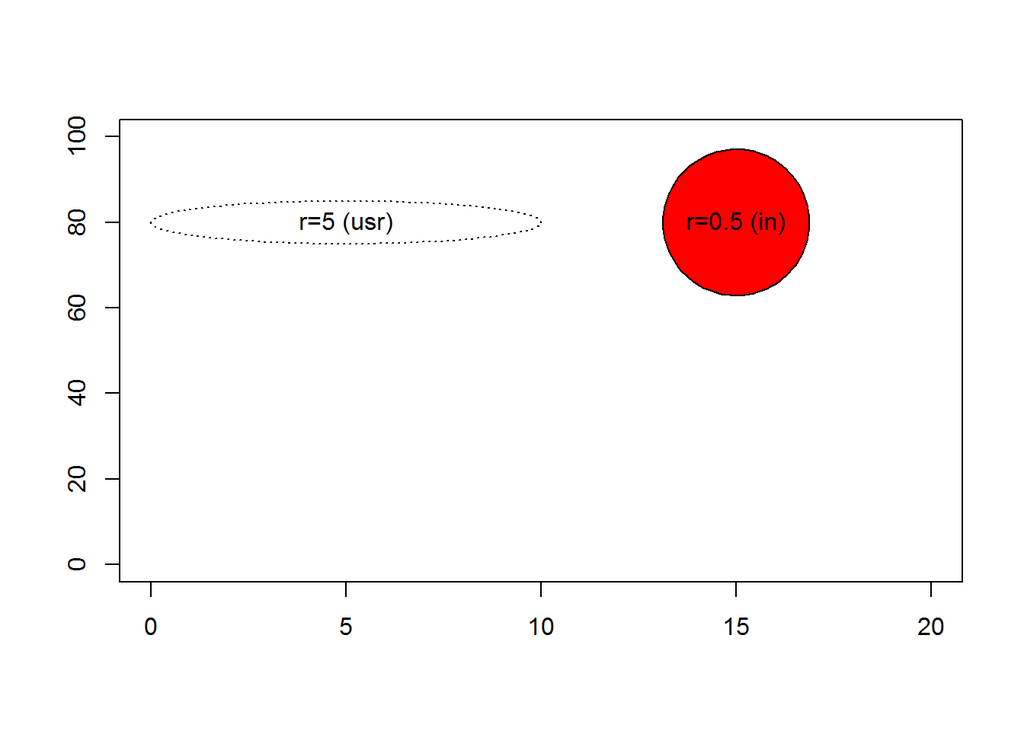

```r
text(15, 80, "r=0.5 (in)")
```

The concept of inches in a graph is a loose one at best. The half inch radius shown above might appears slightly bigger or slightly smaller than a half inch and it will probably change when you move from one computer monitor to another. The size will probably change when you print this graph.

If you’re lucky, the relative size of an inch will mean the same thing in the horizontal and vertical direction, and this will give you a perfect circle, though of an uncertain size. But there is no guarantee even of this. See, for example,

https://cran.r-project.org/bin/windows/base/old/2.0.1/rw-FAQ.html#Circles-appear-as-ovals-on-screen

You may wish to specify the size of your circle in pixels instead. This may or may not be a more stable measure. To do this, you need a measure of pixels per inch.

```r
convert_to_pixels <- function() {
  # This funciton adjusts from user coordinates to pixels.
  # There is a short-cut: ratio <- par("cxy") / par("cra")

  # Range of the plotting region in user coordinates
  plot.range.usr <- c(par("usr")[2] - par("usr")[1], par("usr")[4] - par("usr")[3])
  if (verbose) cat("\nThe range of the plotting region is", plot.range.usr, "in user coordinates")

  # Ratio of pixels to inch
  pixels.per.inch <- dev.size(units="px") / dev.size(units="in")
  if (verbose) cat("\nThere are", pixels.per.inch, "pixels per inch")

  # Range of the plotting region in inches
  plot.range.px <- par("pin") * pixels.per.inch
  if (verbose) cat("\nThe range of the plotting region is", plot.range.px, "in pixels")

  # Number of inches per user coordinate
  ratio <- plot.range.usr / plot.range.px
  if (verbose) cat("\nThere are", ratio, "user coordinates per pixel")
  return(list(x=ratio[1], y=ratio[2]))
}

plot(0, 0, xlim=c(0, 20), ylim=c(0, 100), type="n", xlab=" ", ylab=" ")
draw.circle( 5, 80, 5, lty="dotted")
text( 5, 80, "r=5 (usr)")
verbose <- FALSE
draw.circle(15, 80, 0.5, convert_to_inches, col="red")
text(15, 80, "r=0.5 (in)")
verbose <- TRUE
draw.circle( 2.5, 40, 100, convert_to_pixels, border="blue")
```

```
##
## The range of the plotting region is 21.6 108 in user coordinates
## There are 192 192 pixels per inch
## The range of the plotting region is 1105.92 606.7199 in pixels
## There are 0.01953125 0.1780064 user coordinates per pixel
```

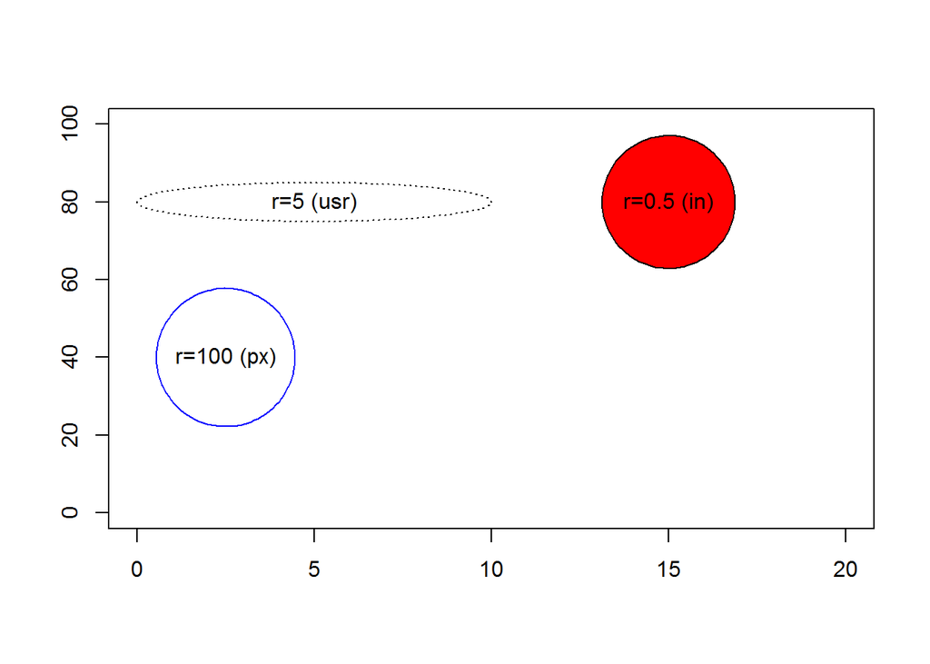

```r
text( 2.5, 40, "r=100 (px)")
```

The results on my computer system may not match the results on your computer system.

If you open a graphics window with the windows() function, you have the option of tweaking this ratio with the xpinch and ypinch arguments. These arguments are not available in most other functions that open a graphics device. These will typically pull a value from your operating system.

A simple modification of this code will allow you to draw a perfect square, diamond, or equilateral triange. Note the fudge factors used to insure the correct lengths of the sides.

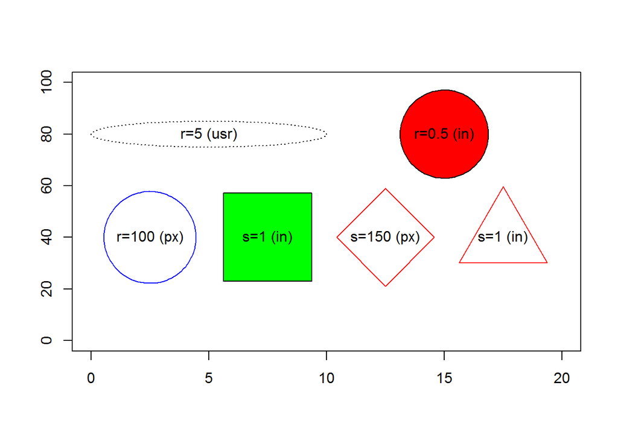

```r
draw.square <- function(x0, y0, s, adjust.units=function() {list(x=1, y=1)}, ...) {
  # draw a circle of radius r centered at x0, y0
  # with an adjustment in the horizontal and vertical dimensions
  # The default adjustment is no adjustment
  pi.seq <- c(1, 3, 5, 7) * pi/4
  adj <- adjust.units()
  x.circle <- x0 + adj$x * s * cos(pi.seq) / sqrt(2)
  y.circle <- y0 + adj$y * s * sin(pi.seq) / sqrt(2)
  polygon(x.circle, y.circle, ...)
}

draw.diamond <- function(x0, y0, s, adjust.units=function() {list(x=1, y=1)}, ...) {
  # draw a circle of radius r centered at x0, y0
  # with an adjustment in the horizontal and vertical dimensions
  # The default adjustment is no adjustment
  pi.seq <- (0:3) * pi/2
  adj <- adjust.units()
  x.circle <- x0 + adj$x * s * cos(pi.seq) / sqrt(2)
  y.circle <- y0 + adj$y * s * sin(pi.seq) / sqrt(2)
  polygon(x.circle, y.circle, ...)
}

draw.triangle <- function(x0, y0, s, adjust.units=function() {list(x=1, y=1)}, ...) {
  # draw a circle of radius r centered at x0, y0
  # with an adjustment in the horizontal and vertical dimensions
  # The default adjustment is no adjustment
  pi.seq <- pi/2 + (0:2) * 2*pi/3
  adj <- adjust.units()
  x.circle <- x0 + adj$x * s * cos(pi.seq) * sqrt(1/3)
  y.circle <- y0 + adj$y * s * sin(pi.seq) * sqrt(1/3)
  polygon(x.circle, y.circle, ...)
}

plot(0, 0, xlim=c(0, 20), ylim=c(0, 100), type="n", xlab=" ", ylab=" ")
draw.circle( 5, 80, 5, lty="dotted")
text( 5, 80, "r=5 (usr)")
verbose <- FALSE
draw.circle(15, 80, 0.5, convert_to_inches, col="red")
text(15, 80, "r=0.5 (in)")
draw.circle( 2.5, 40, 100, convert_to_pixels, border="blue")
text( 2.5, 40, "r=100 (px)")
draw.square(7.5, 40, 1, convert_to_inches, col="green")
text(7.5, 40, "s=1 (in)")
draw.diamond(12.5, 40, 150, convert_to_pixels, border="red")
text(12.5, 40, "s=150 (px)")
draw.triangle(17.5, 40, 1, convert_to_inches, border="red")
text(17.5, 40, "s=1 (in)")
```

Let’s see how these functions can help with string rotation.

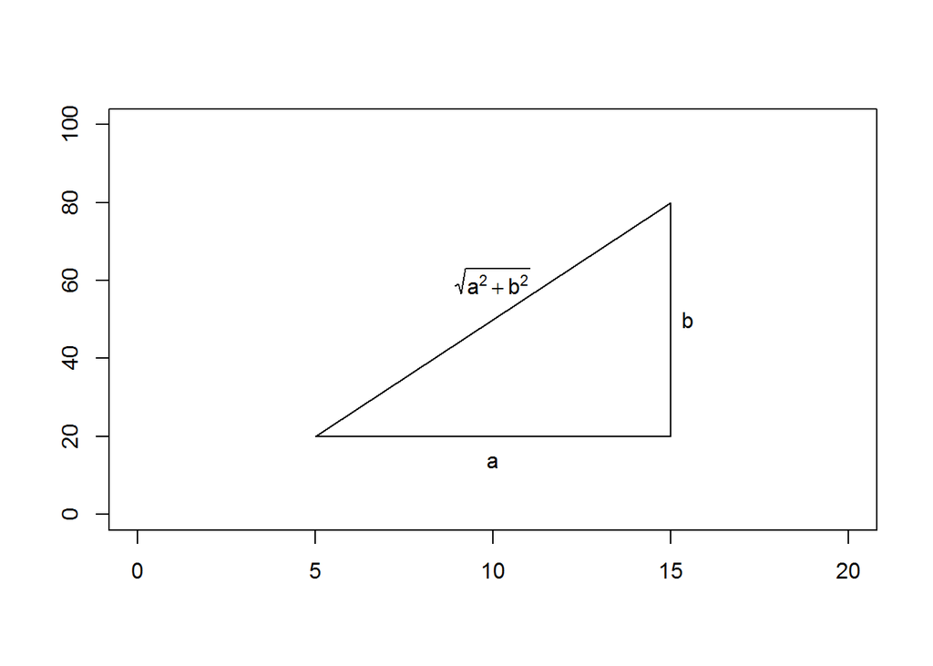

```r
plot(0, 0, xlim=c(0, 20), ylim=c(0, 100), type="n", xlab=" ", ylab=" ")
lines(x=c(5, 15, 15, 5), y=c(20, 20, 80, 20))
text(10, 20-1.5*strheight("a", units="user"), "a")
text(15+1.5*strwidth("b"), 50, "b")
ctext <- expression(sqrt(a^2+b^2))
text(10, 50+1.5*strheight(ctext), ctext)
```

That looks nice, but wouldn’t it be better if you could tilt the formula on the hypotenuse? You can do this with the srt argument, but you need to rotate in the dimensions of the graph (in inches or pixels).

```r
plot(0, 0, xlim=c(0, 20), ylim=c(0, 100), type="n", xlab=" ", ylab=" ")
lines(x=c(5, 15, 15, 5), y=c(20, 20, 80, 20))
text(10, 20-1.5*strheight("a", units="user"), "a")
text(15+1.5*strwidth("b"), 50, "b")
delta.x <- 15-5
delta.y <- 80-20
adj <- convert_to_inches()
print(adj)
```

```
## $x
## [1] 3.75
##
## $y
## [1] 34.17722
```

```r
hyp.angle <- atan2(delta.y/adj$y, delta.x/adj$x) * 180 / pi
print(hyp.angle)
```

```
## [1] 33.35824
```

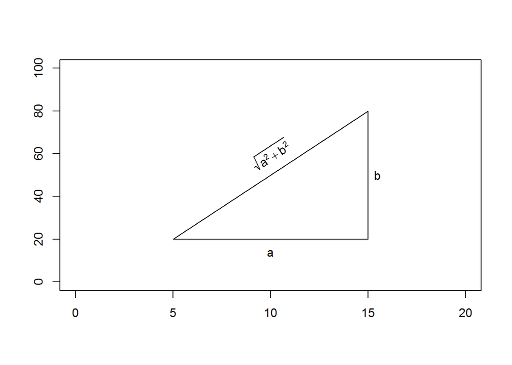

```r
ctext <- expression(sqrt(a^2+b^2))
text(10, 50+1.5*strheight(ctext), ctext, srt=hyp.angle)
```